# Portuguese Bank Marketing Data

Team ID: Group 25

- Truc Le (trlle@ucdavis.edu)- (Data Wrangling, Data Exploration, visualization, Leading the Team, Coding, Primary Question, Stitching report together)
- Mengna Lin (menlin@ucdavis.edu)- (Introduction- background, Literature review, Reference citation, Leading the team,Editing final report)
- Lik Xian Lim (lxlim@ucdavis.edu)- (Analysis Plan, Literature Review, Extra Credit Method, Inferential Analysis of Extra Credit method, Leading the Team, Editing the report)
- Mary Vang (marvang@ucdavis.edu)- (Exploratory Analysis Interpretation, Main Analysis and Methods Interpretation, Results - Inferential Analysis, Secondary Question, Leading the Team (Meeting Agenda))

# 1 Introduction

## 1.1 Background

In this project, we analyze empirical data from a 2008 telemarketing campaign from a Portuguese retail bank aimed at subscribing new users to a term deposit. The authors of the original data focus on evaluating different methods that can be used to determine the extent to which bank telemarketing is successful at predicting the likelihood of a client subscribing to a long-term deposit. The dataset is available for download from the UCI Machine Learning Repository at [the link](https://archive.ics.uci.edu/ml/datasets/Bank+Marketing#) along with more information in the original paper by Moro, Cortez, and Rita (2014).

For our specific project, we will be analyzing the “bank-additional-full.csv” that includes a variety of predictor variables to address our primary question of interest: build an effective prediction model for whether a client will sign onto a long-term deposit. Our secondary question of interest focuses on identifying the “type” of client data (bank telemarketing, campaign, socio-economic, and individual background) most pivotal in determining whether a client will sign onto a long-term deposit. We focus on three primary statistical tools for analyzing and better visualizing potential relationships between our variables: decision trees, logistic regression, and k-nearest neighbor. According to Decision Trees for Analytics: Using SAS Enterprise Miner, decision trees have been useful in substituting and supporting various forms of multiple variable analysis including traditional forms of multivariate analysis (ie. multiple linear regression), data mining tools and techniques (ie. neutral networks), and multidimensional forms of reporting and analysis. By being able to combine categories that have similar values into ranges that align with some target value, we see improvement in prediction and classification results as less information is being lost when collapsing a set of categorical variables together [1]. Considering the varying units and level of measurements in our dataset, a decision tree is desirable for its relative power, flexibility with a variety of data, and ease of interpretability.

As for logistic regression, it has been one of the most widely used statistical tools for analyzing binary and proportional response data. Basic logistic regression models can be used to examine relationships between binary response variables and independent response variables that come in many forms (ie. binary, continuous, categorical) [2]. In logistic regression, we assess the goodness of fit and predictive utility of the model, and turn to regression coefficients and inferential statistics to determine the significance of individual predictors [4]. Due to its flexibility with a variety of data, ease of implementation in statistical software algorithms, and consistency with assumptions in real-world empirical data, logistic regression models have been used to understand complex relationships from a variety of disciplines emphasizing prediction and causality.

Regarding k-Nearest Neighbor (k-NN), it has been widely used as a non-parametric statistical technique for applied statistical estimation and pattern recognition, while also being known as an instance based learning type, where everything is approximated regionally, and computation is suspended till classification [3]. According to Application of k-NN and Naïve Bayes Algorithm in Banking and Insurance Domain, the k-NN algorithm rule is one of the most useful among machine learning algorithms. By comparing a testing dataset to the existing samples within a training dataset, using a distance measurement technique, we can appropriately classify a dataset without having to create any assumptions regarding the distribution of both our training and testing datasets. Since the k-NN algorithm can be applied for classification or regression, there is more flexibility as to how we want to apply k-NN to best address our statistical questions of interest.

[1] De Ville, Barry, and Padraic Neville. Decision Trees for Analytics: Using SAS Enterprise Miner. Cary, NC: SAS Institute, 2013.

[2] Hilbe, Joseph M. Logistic regression models. CRC press, 2009.

[3] Rahangdale, Gourav, Manish Ahirwar, and Mahesh Motwani. "Application of k-NN and Naive Bayes Algorithm in Banking and Insurance Domain." International Journal of Computer Science Issues (IJCSI) 13, no. 5 (2016): 69.

[4] Salkind, Neil J., ed. Encyclopedia of research design. Vol. 1. Sage, 2010.

## 1.2 Statistical questions of interest

To answer the primary question of interest, we propose visualizing our data with a decision tree, then using k-nearest neighbor to classify our dataset, and finally using logistic regression to frame our model. In terms of our secondary question, we will use data exploratory analysis with half of our variables to infer which data type is our strongest predictor for client subscription.

- 1. Primary Question: Build a prediction model for whether a client will sign on to a long-term deposit.
- 2. Secondary Question: What type of client data from our dataset most strongly predicts if a client will sign onto a long-term deposit? (e.g. Customer Background Data, Telemarketing Data, Economic Data, Other)

# 2 Analysis Plan

The bank-additional-full data consists of different client data with variables including age, marital status, gender, education, job, etc.. The purpose of the original data was aimed at determining whether or not there was a significant relationship between different predictor variables, and what directly affects clients in deciding whether or not to subscribe onto a long-term deposit. A prediction model can be built to better understand the different factors that play a role in their decision. We choose the following variables to be analyzed: duration, campaign, emp.var.rate, cons.price.idx, cons.conf.idx, euribor3m, nr.employed, job, marital, education, default, housing, loan, contact, month, day of week, and outcome. In doing so, we were able to identify through correlation testing for the numeric variables the factors that affect the deposit decisions.

We used predictive models such as **classification trees** to visualise the data such that the target’s variable values could be predicted on other values, **k- Nearest Neighbor** to approximate the association between the independent variables and the continuous outcomes, and **logistic regression** to frame our binary output model through logistic function. We also used a **Support Vector Matrix (SVM)** which was used to predict the decision which has a higher sensitivity with less computation on the long term deposit based on the factors.

## 2.1 Population and study design

We identified the main key attributes that are significant to the study used. This also includes determining the data type, ie. whether a variable is continuous or categorical. The study did analyze the attributes, and identified the significance of each variable on the outcome.

- Our 20 attributes can be categorized into 4 types of different client data:
1. Client background data: age, job, marital status, education, default, housing, and loan
2. Bank telemarketing data: contact, month, day of the week, and duration
3. Socio-economic data: employment variation rate, consumer price index, consumer confidence index, 3 month Euribor rate, and number of employees 4.Other data: campaign, past days, previous, and past outcome

We will be focusing on this attribute categorization and applying exploratory analysis to answer our secondary question.

### Definition of Input Variables

**age** - Age of the client- (numeric)

**job** - Client’s occupation - (categorical) (admin, bluecollar, entrepreneur, housemaid, management, retired, selfemployed, services, student, technician, unemployed, unknown)

**marital** - Client’s marital status - (categorical) (divorced, married, single, unknown, note: divorced means divorced or widowed)

**education** - Client’s education level - (categorical) (basic.4y, basic.6y, basic.9y, high.school, illiterate, professional.course, university.degree, unknown)

**default** - Indicates if the client has credit in default - (categorical) (no, yes, unknown)

**housing** - Does the client as a housing loan? - (categorical) (no, yes, unknown)

**loan** - Does the client as a personal loan? - (categorical) (no, yes, unknown’)

**contact** - Type of communication contact - (categorical) (cellular, telephone)

**month** - Month of last contact with client - (categorical) (January - December)

**day_of_week** - Day of last contact with client - (categorical) (Monday - Friday)

**duration** - Duration of last contact with client, in seconds - (numeric) For benchmark purposes only, and not reliable for predictive modeling

**campaign** - Number of client contacts during this campaign - (numeric) (includes last contact)

**pdays** - Number of days from last contacted from a previous campaign - (numeric) (999 means client was not previously contacted)

**previous** - Number of client contacts performed before this campaign - (numeric)

**poutcome** - Previous marketing campaign outcome - (categorical) (failure, nonexistent , success)

**emp.var.rate** - Quarterly employment variation rate - (numeric)

**cons.price.idx** - Monthly consumer price index - (numeric)

**cons.conf.idx** - Monthly consumer confidence index - (numeric)

**euribor3m** - Daily euribor 3 month rate - (numeric)

**nr.employed** - Quarterly number of employees - (numeric)

Output variable (desired target) - **Term Deposit** - subscription verified (binary: ‘yes’,‘no’)

## 2.2 Statistical Analysis

### 2.2.1 Descriptive Analysis

#### 2.2.1.1 Set up and Data Wrangling

Transform all of the quantitative values into numeric class for easier manipulation later on. See how many rows have missing data

```r
# this allows for the data to be separated rather than being mushed together.
# to see how many rows have missing data
sum(!complete.cases(bank_additional_full))
```

```
## [1] 0
```

Show the missing values within the dataset for each categories

```
##            age            job        marital      education        default
##              0              0              0              0              0
##        housing           loan        contact          month    day_of_week
##              0              0              0              0              0
##       duration       campaign          pdays       previous       poutcome
##              0              0              0              0              0
##   emp.var.rate cons.price.idx  cons.conf.idx      euribor3m    nr.employed
##              0              0              0              0              0
##              y
##              0
```

Write the clean data into a separate csv that we can work with, and get rid of a column in our new dataset when we go to read it.

Transform all of the quantitative values into numeric class for easier manipulation later on.

```r
bank$age <- as.numeric(bank$age)
bank$duration <- as.numeric(bank$duration)
bank$campaign <- as.numeric(bank$campaign)
bank$pdays <- as.numeric(bank$pdays)
bank$previous <- as.numeric(bank$previous)
bank$emp.var.rate <- as.numeric(bank$emp.var.rate)
bank$cons.price.idx <- as.numeric(bank$cons.price.idx)
bank$cons.conf.idx <- as.numeric(bank$cons.conf.idx)
bank$nr.employed <- as.numeric(bank$nr.employed)
```

Checking if there are any missing data within each categories and push them into a category of there own. Change the subscription category into binary as well.

```r
bank$job = fct_explicit_na(bank$job, "missing")
bank$marital = fct_explicit_na(bank$marital, "missing")
bank$education = fct_explicit_na(bank$education, "missing")
bank$default = fct_explicit_na(bank$default, "missing")
bank$loan = fct_explicit_na(bank$loan, "missing")
bank$contact = fct_explicit_na(bank$contact, "missing")
bank$poutcome = fct_explicit_na(bank$poutcome, "missing")
bank$day_of_week = fct_explicit_na(bank$day_of_week, "missing")
bank$housing = fct_explicit_na(bank$housing, "missing")
bank$month = fct_explicit_na(bank$month, "missing")
bank$y =ifelse(bank$y =='yes',1,0) # transforming 'yes' category into a binary 1=yes 0=no
```

#### 2.2.1.2 Exploratory Analysis

##### Summary of the Bank Additional Full Data set

##### **Data Structure of Dataset**

```
## 'data.frame':    41188 obs. of  21 variables:
##  $ age           : num  56 57 37 40 56 45 59 41 24 25 ...
##  $ job           : Factor w/ 12 levels "admin.","blue-collar",..: 4 8 8 1 8 8 1 2 10 8 ...
##  $ marital       : Factor w/ 4 levels "divorced","married",..: 2 2 2 2 2 2 2 2 3 3 ...
##  $ education     : Factor w/ 8 levels "basic.4y","basic.6y",..: 1 4 4 2 4 3 6 8 6 4 ...
##  $ default       : Factor w/ 3 levels "no","unknown",..: 1 2 1 1 1 2 1 2 1 1 ...
##  $ housing       : Factor w/ 3 levels "no","unknown",..: 1 1 3 1 1 1 1 1 3 3 ...
##  $ loan          : Factor w/ 3 levels "no","unknown",..: 1 1 1 1 3 1 1 1 1 1 ...
##  $ contact       : Factor w/ 2 levels "cellular","telephone": 2 2 2 2 2 2 2 2 2 2 ...
##  $ month         : Factor w/ 10 levels "apr","aug","dec",..: 7 7 7 7 7 7 7 7 7 7 ...
##  $ day_of_week   : Factor w/ 5 levels "fri","mon","thu",..: 2 2 2 2 2 2 2 2 2 2 ...
##  $ duration      : num  261 149 226 151 307 198 139 217 380 50 ...
##  $ campaign      : num  1 1 1 1 1 1 1 1 1 1 ...
##  $ pdays         : num  999 999 999 999 999 999 999 999 999 999 ...
##  $ previous      : num  0 0 0 0 0 0 0 0 0 0 ...
##  $ poutcome      : Factor w/ 3 levels "failure","nonexistent",..: 2 2 2 2 2 2 2 2 2 2 ...
##  $ emp.var.rate  : num  1.1 1.1 1.1 1.1 1.1 1.1 1.1 1.1 1.1 1.1 ...
##  $ cons.price.idx: num  94 94 94 94 94 ...
##  $ cons.conf.idx : num  -36.4 -36.4 -36.4 -36.4 -36.4 -36.4 -36.4 -36.4 -36.4 -36.4 ...
##  $ euribor3m     : num  4.86 4.86 4.86 4.86 4.86 ...
##  $ nr.employed   : num  5191 5191 5191 5191 5191 ...
##  $ y             : num  0 0 0 0 0 0 0 0 0 0 ...
```

##### **Summary of the Data set**

|  | age | job | marital | education | default | housing | loan | contact | month | day_of_week | duration | campaign | pdays | previous | poutcome | emp.var.rate | cons.price.idx | cons.conf.idx | euribor3m | nr.employed | y |
| --- | --- | --- | --- | --- | --- | --- | --- | --- | --- | --- | --- | --- | --- | --- | --- | --- | --- | --- | --- | --- | --- |
|  | Min. :17.00 | admin. :10422 | divorced: 4612 | university.degree :12168 | no :32588 | no :18622 | no :33950 | cellular :26144 | may :13769 | fri:7827 | Min. : 0.0 | Min. : 1.000 | Min. : 0.0 | Min. :0.000 | failure : 4252 | Min. :-3.40000 | Min. :92.20 | Min. :-50.8 | Min. :0.634 | Min. :4964 | Min. :0.0000 |
|  | 1st Qu.:32.00 | blue-collar: 9254 | married :24928 | high.school : 9515 | unknown: 8597 | unknown: 990 | unknown: 990 | telephone:15044 | jul : 7174 | mon:8514 | 1st Qu.: 102.0 | 1st Qu.: 1.000 | 1st Qu.:999.0 | 1st Qu.:0.000 | nonexistent:35563 | 1st Qu.:-1.80000 | 1st Qu.:93.08 | 1st Qu.:-42.7 | 1st Qu.:1.344 | 1st Qu.:5099 | 1st Qu.:0.0000 |
|  | Median :38.00 | technician : 6743 | single :11568 | basic.9y : 6045 | yes : 3 | yes :21576 | yes : 6248 | NA | aug : 6178 | thu:8623 | Median : 180.0 | Median : 2.000 | Median :999.0 | Median :0.000 | success : 1373 | Median : 1.10000 | Median :93.75 | Median :-41.8 | Median :4.857 | Median :5191 | Median :0.0000 |
|  | Mean :40.02 | services : 3969 | unknown : 80 | professional.course: 5243 | NA | NA | NA | NA | jun : 5318 | tue:8090 | Mean : 258.3 | Mean : 2.568 | Mean :962.5 | Mean :0.173 | NA | Mean : 0.08189 | Mean :93.58 | Mean :-40.5 | Mean :3.621 | Mean :5167 | Mean :0.1127 |
|  | 3rd Qu.:47.00 | management : 2924 | NA | basic.4y : 4176 | NA | NA | NA | NA | nov : 4101 | wed:8134 | 3rd Qu.: 319.0 | 3rd Qu.: 3.000 | 3rd Qu.:999.0 | 3rd Qu.:0.000 | NA | 3rd Qu.: 1.40000 | 3rd Qu.:93.99 | 3rd Qu.:-36.4 | 3rd Qu.:4.961 | 3rd Qu.:5228 | 3rd Qu.:0.0000 |
|  | Max. :98.00 | retired : 1720 | NA | basic.6y : 2292 | NA | NA | NA | NA | apr : 2632 | NA | Max. :4918.0 | Max. :56.000 | Max. :999.0 | Max. :7.000 | NA | Max. : 1.40000 | Max. :94.77 | Max. :-26.9 | Max. :5.045 | Max. :5228 | Max. :1.0000 |
|  | NA | (Other) : 6156 | NA | (Other) : 1749 | NA | NA | NA | NA | (Other): 2016 | NA | NA | NA | NA | NA | NA | NA | NA | NA | NA | NA | NA |

##### **Frequency of Response Variable**

| Var1 | Freq |
| --- | --- |
| 0 | 0.8873458 |
| 1 | 0.1126542 |

After observing the frequency of the response variable, it is evident that the predicted outcome (y) is skewed to "no"" by 88.8%

#### Age

The majority of clients are between the ages of 32 (1st Quartile) and 47 (3rd Quartile) with a mean of about 40 as indicated by the red vertical line on the histogram.

| Min. | 1st Qu. | Median | Mean | 3rd Qu. | Max. |
| --- | --- | --- | --- | --- | --- |
| 17 | 32 | 38 | 40.02 | 47 | 98 |

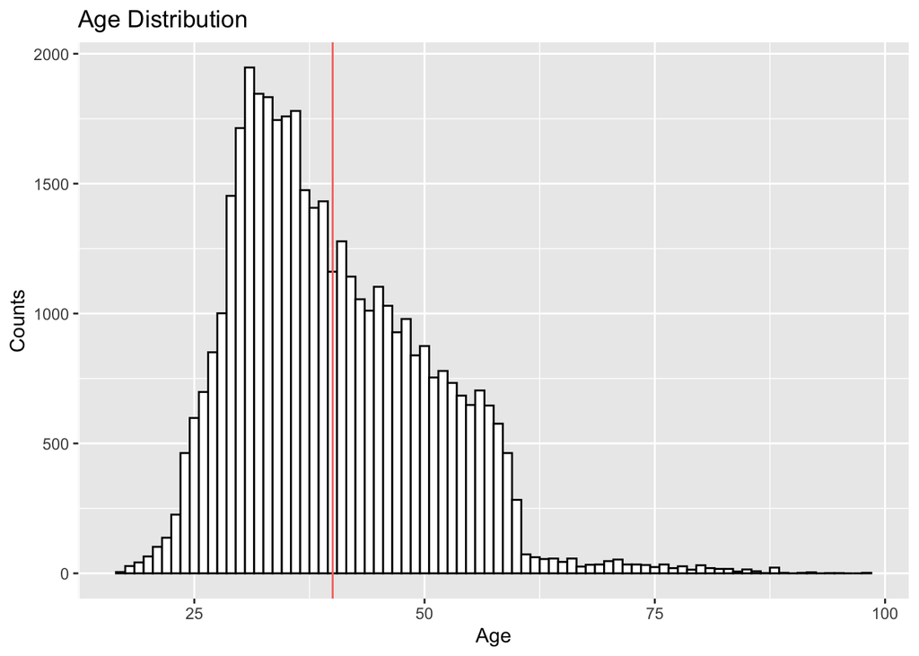

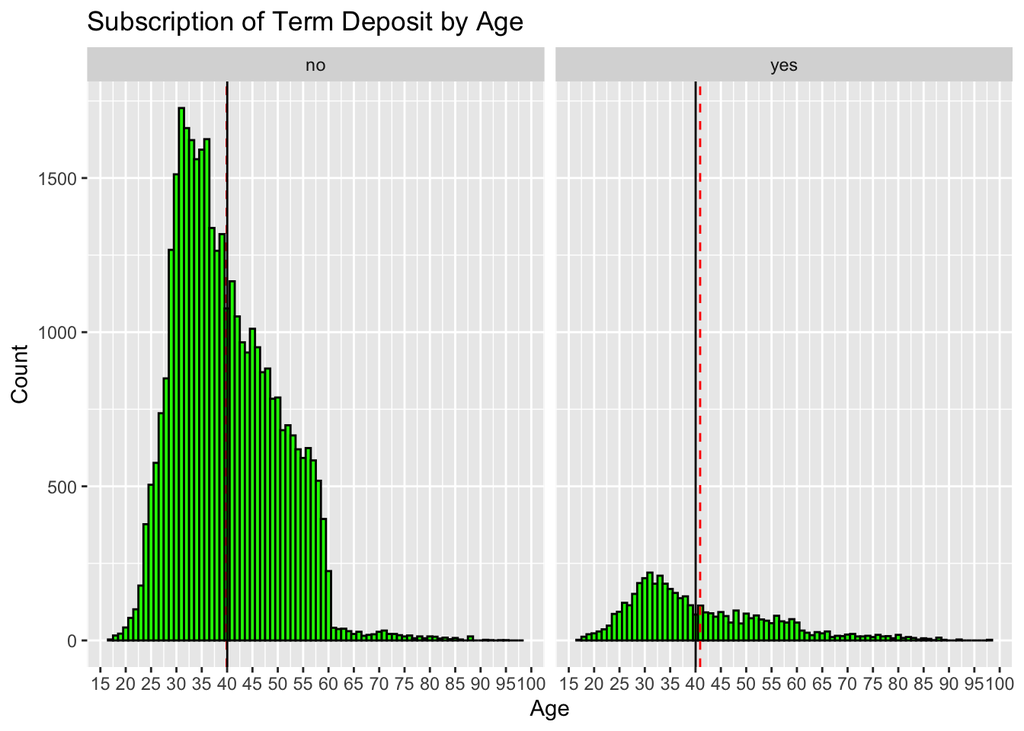

Age Percentage to Subscribe

| age | age.cnt | pct.con.yes |
| --- | --- | --- |
| 31 | 1947 | 11.299435 |
| 32 | 1846 | 9.967497 |
| 33 | 1833 | 11.456629 |
| 36 | 1780 | 8.651685 |
| 35 | 1759 | 9.494031 |
| 34 | 1745 | 10.544413 |

#### Education

Having higher education is seen to contribute to higher subscription of a term deposit. Most clients who subscribe have received secondary education or above. In addition, clients with university degrees seem to have a higher rate of subscription compared to other clients.

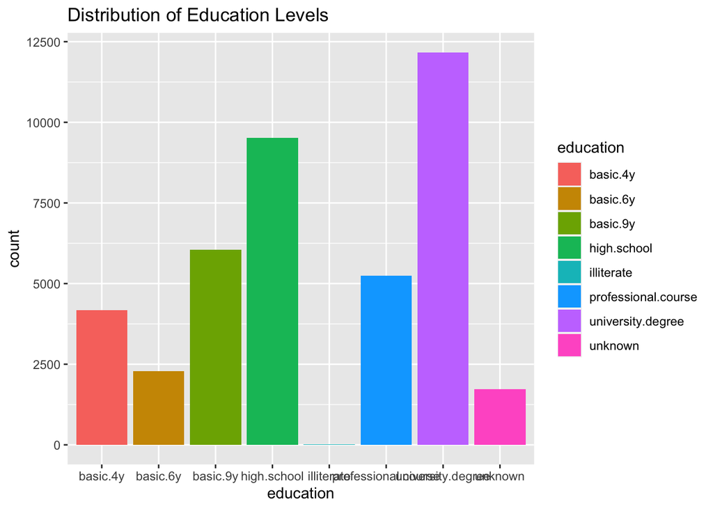

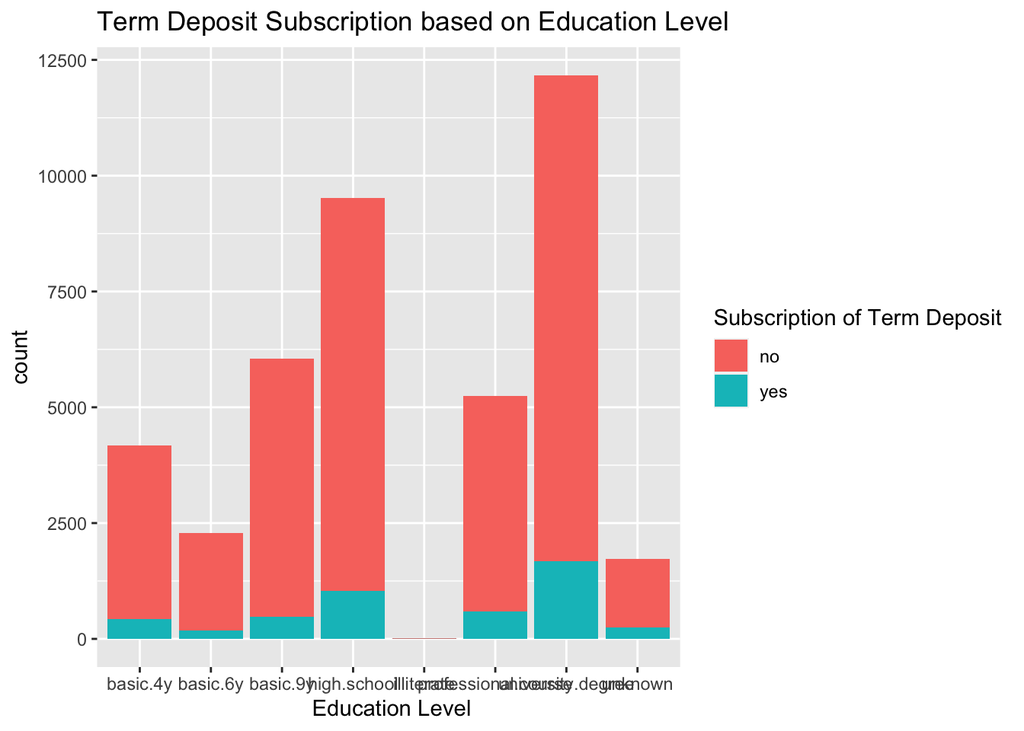

Education Percentage to Subscribe

| education | edu.cnt | pct.con.yes |
| --- | --- | --- |
| university.degree | 12168 | 13.724523 |
| high.school | 9515 | 10.835523 |
| basic.9y | 6045 | 7.824649 |
| professional.course | 5243 | 11.348465 |
| basic.4y | 4176 | 10.249042 |
| basic.6y | 2292 | 8.202443 |

#### Job

The majority of clients have administrative, blue-collar, or technician jobs. However, the students and those retired have the highest job percentage (31.4% and 25.3% respectively) known to subscribe.

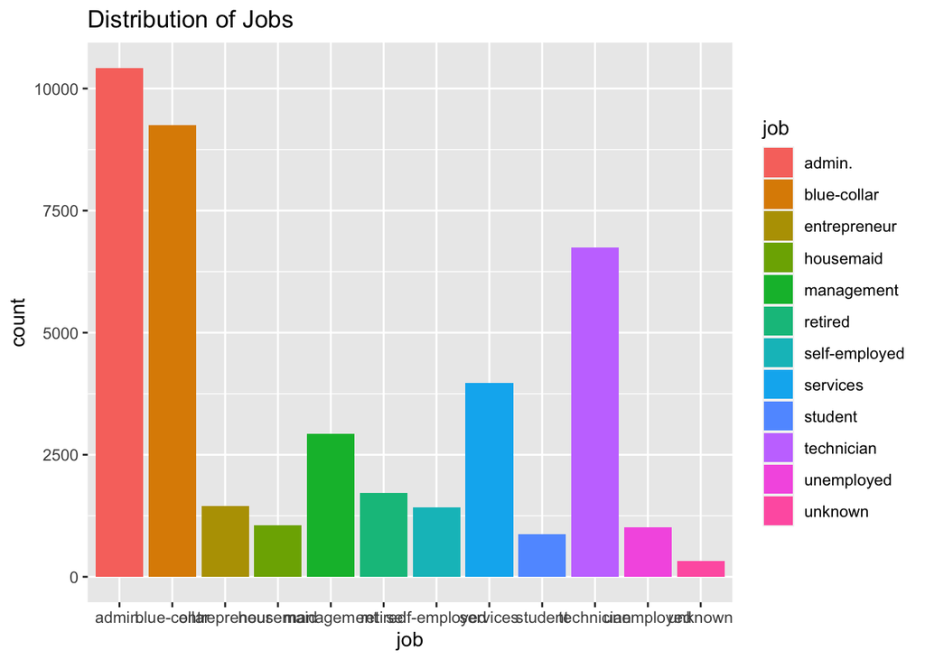

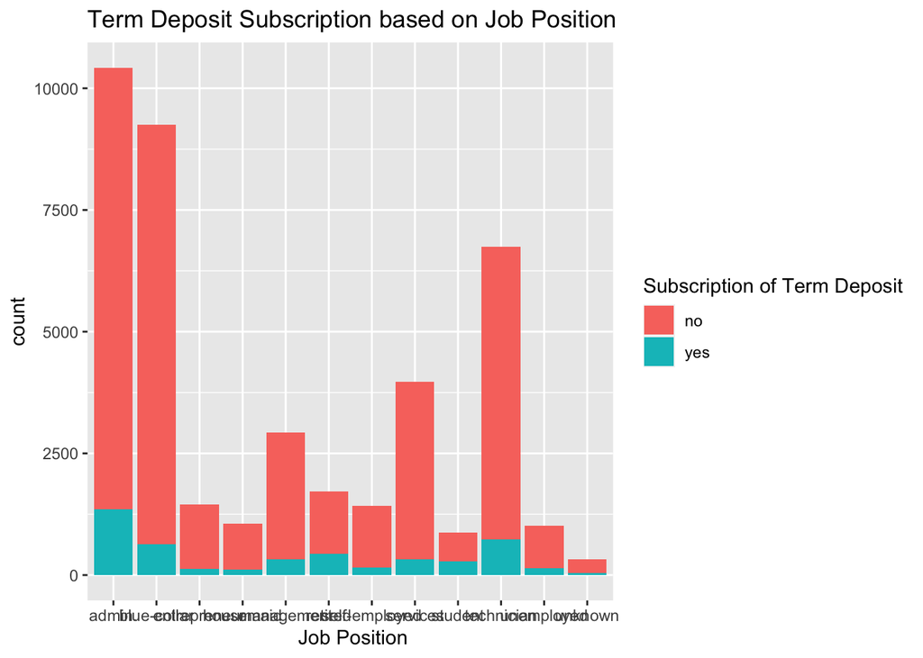

Job Percentage to Subscribe

| job | job.cnt | pct.con.yes |
| --- | --- | --- |
| admin. | 10422 | 12.972558 |
| blue-collar | 9254 | 6.894316 |
| technician | 6743 | 10.826042 |
| services | 3969 | 8.138070 |
| management | 2924 | 11.217510 |
| retired | 1720 | 25.232558 |

#### Marital Status

The majority of clients are married. However, the percentage of those who are married, divorced or single are roughly similar in terms of likelihood of subscription.

marital Percentage to Subscribe

| marital | marital.cnt | pct.con.yes |
| --- | --- | --- |
| married | 24928 | 10.15725 |
| single | 11568 | 14.00415 |
| divorced | 4612 | 10.32090 |
| unknown | 80 | 15.00000 |

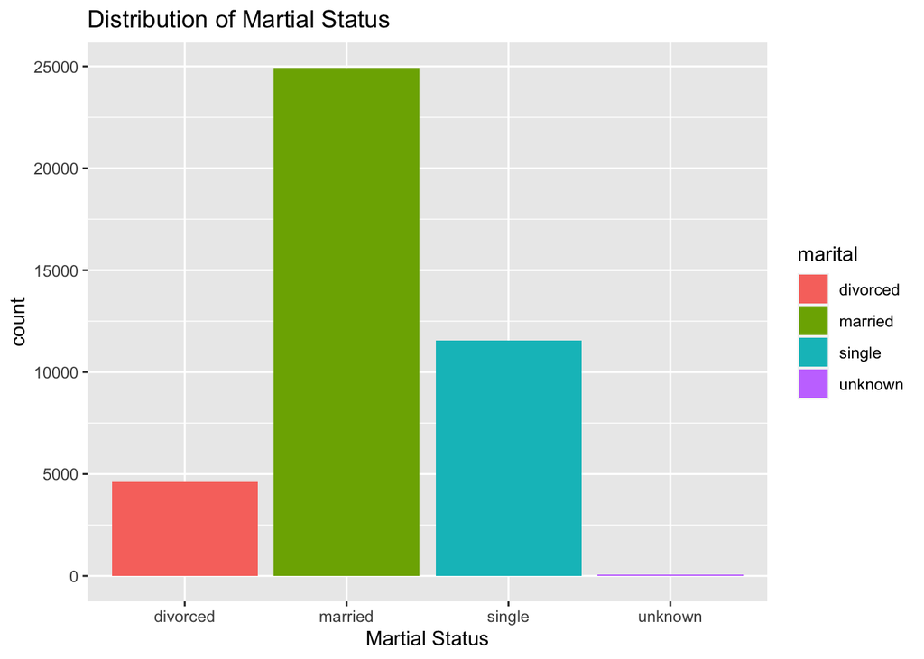

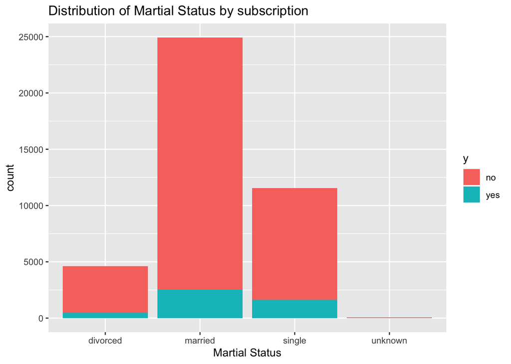

#### Consumer Price Index

The monthly consumer price index either does not display enough, or displays excess information for us to draw conclusions from. Therefore, we can go ahead and disregard this variable when considering our secondary question.

Consumer Price Index Percentage to Subscribe

| cons.price.idx | cpi.cnt | pct.con.yes |
| --- | --- | --- |
| 93.994 | 7763 | 3.091588 |
| 93.918 | 6685 | 6.088257 |
| 92.893 | 5794 | 9.043838 |
| 93.444 | 5175 | 5.236715 |
| 94.465 | 4374 | 4.298125 |
| 93.200 | 3616 | 5.254425 |

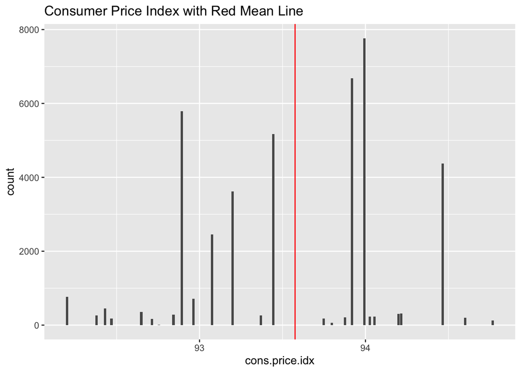

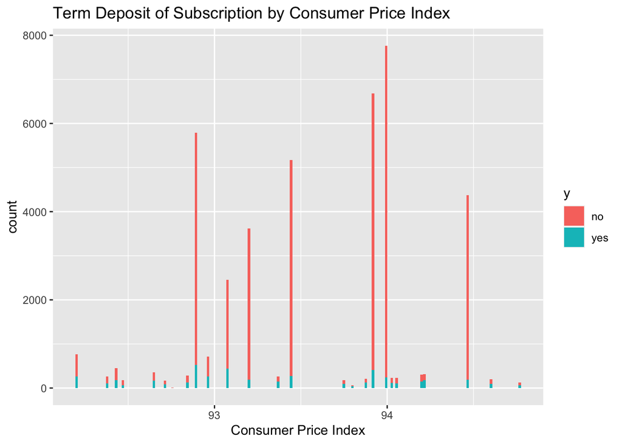

#### Consumer Confidence Index

The majority of clients have a consumer confidence index between -46 to -36. However, from the red bar graph, it is evident the clients’ consumer confidence index percentage of subscribing is very low (which we can consider irrelevant).

Consumer Confidence Index Percentage to Subscribe

| cons.conf.idx | cci.cnt | pct.con.yes |
| --- | --- | --- |
| -36.4 | 7763 | 3.091588 |
| -42.7 | 6685 | 6.088257 |
| -46.2 | 5794 | 9.043838 |
| -36.1 | 5175 | 5.236715 |
| -41.8 | 4374 | 4.298125 |
| -42.0 | 3616 | 5.254425 |

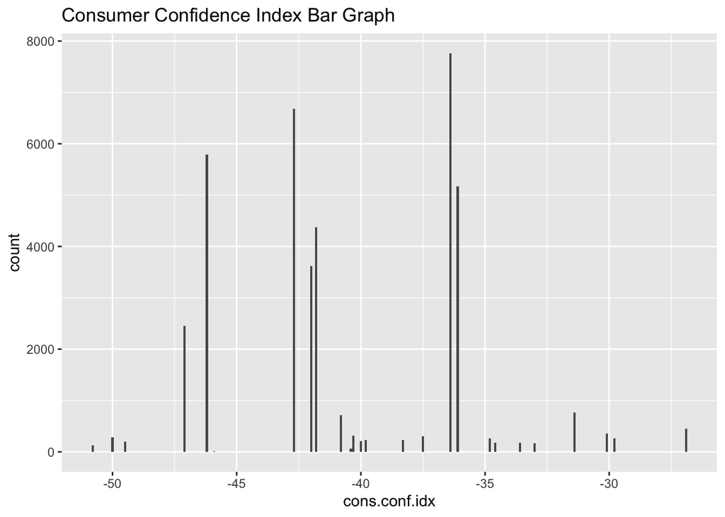

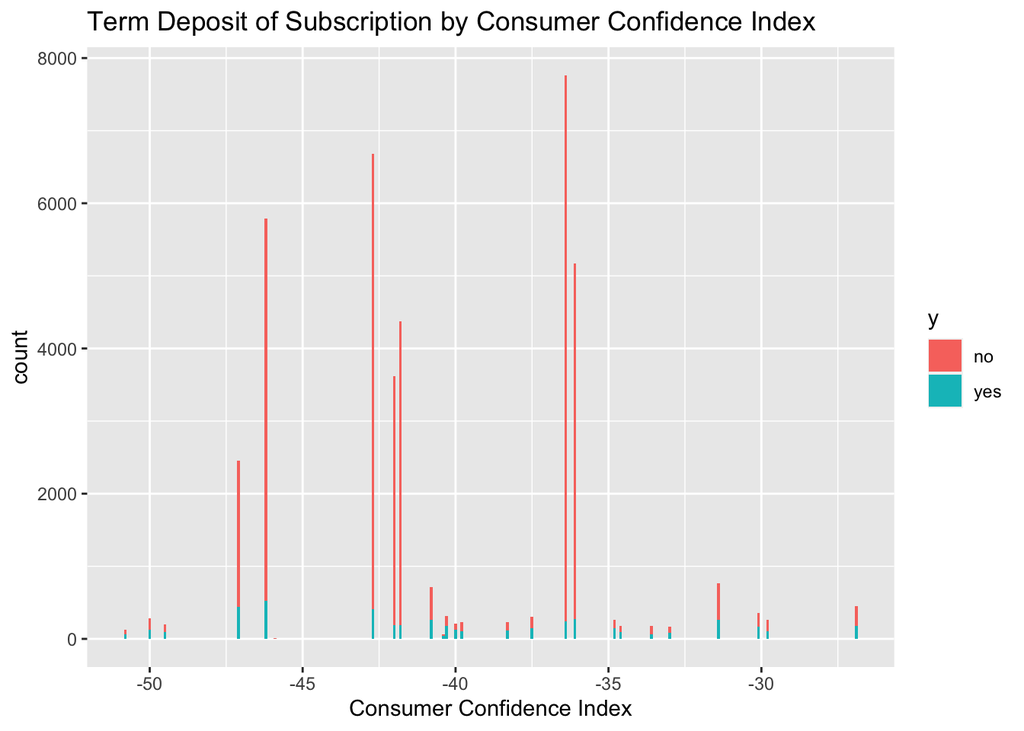

#### Campaign

Campaign Percentage to Subscribe

| campaign | contact.cnt | pct.con.yes |
| --- | --- | --- |
| 1 | 17642 | 13.037071 |
| 2 | 10570 | 11.456954 |
| 3 | 5341 | 10.747051 |
| 4 | 2651 | 9.392682 |
| 5 | 1599 | 7.504690 |
| 6 | 979 | 7.660878 |

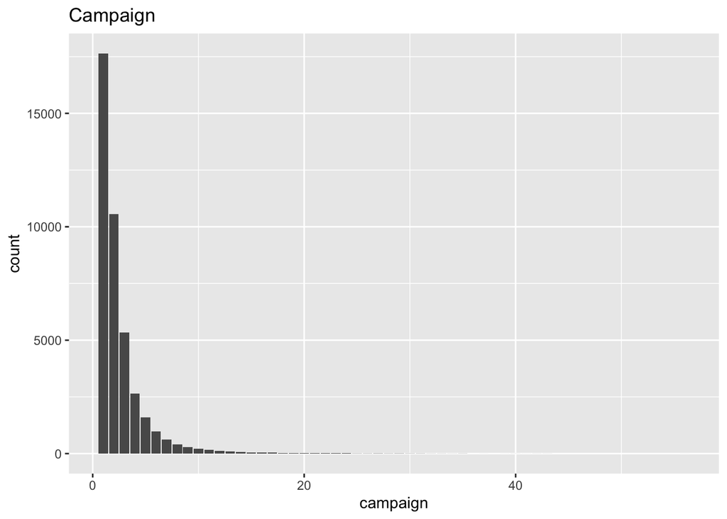

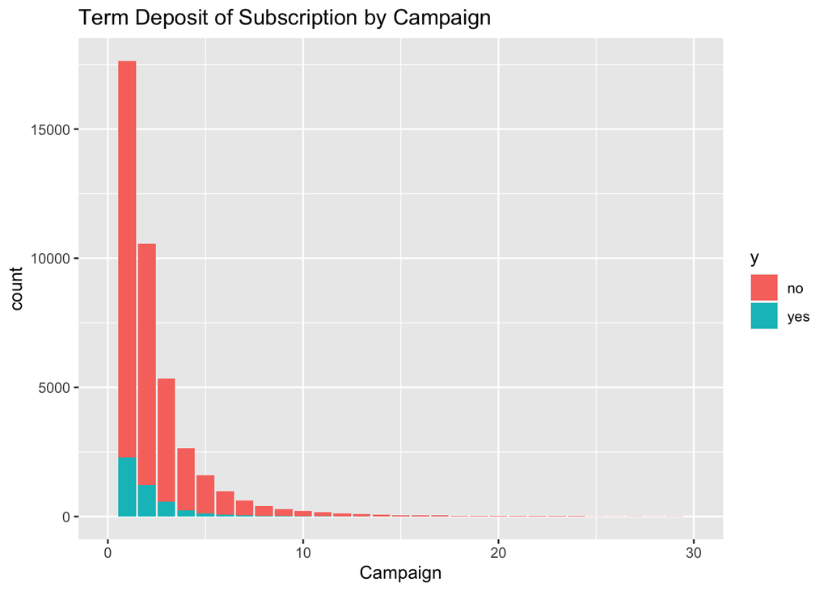

#### Duration

Duration Percentage to Subscribe

| duration | contact.cnt | pct.con.yes |
| --- | --- | --- |
| 85 | 170 | 1.1764706 |
| 90 | 170 | 1.1764706 |
| 136 | 168 | 4.7619048 |
| 73 | 167 | 0.5988024 |
| 124 | 164 | 2.4390244 |
| 87 | 162 | 1.8518519 |

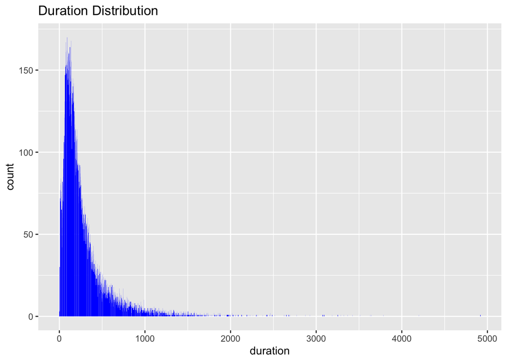

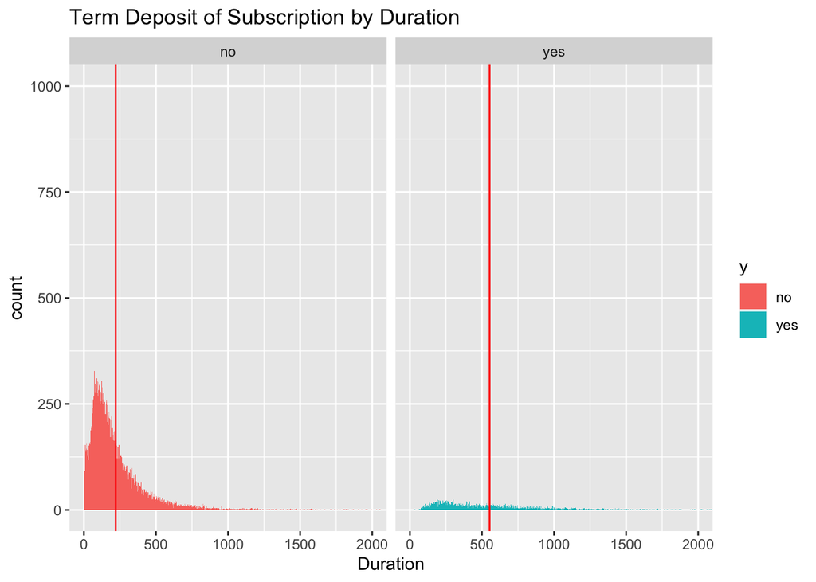

#### Employment Variation Rate

Employment Variation Rate Percentage to Subscribe

| emp.var.rate | contact.cnt | pct.con.yes |
| --- | --- | --- |
| 1.4 | 16234 | 5.334483 |
| -1.8 | 9184 | 15.908101 |
| 1.1 | 7763 | 3.091588 |
| -0.1 | 3683 | 6.299213 |
| -2.9 | 1663 | 35.718581 |
| -3.4 | 1071 | 42.390289 |

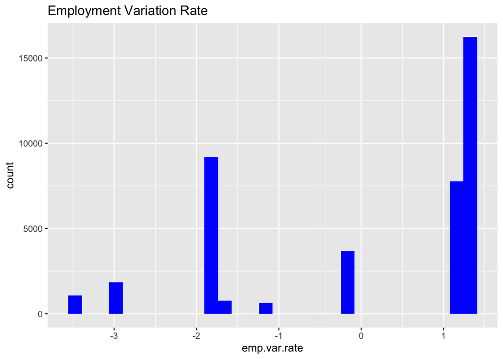

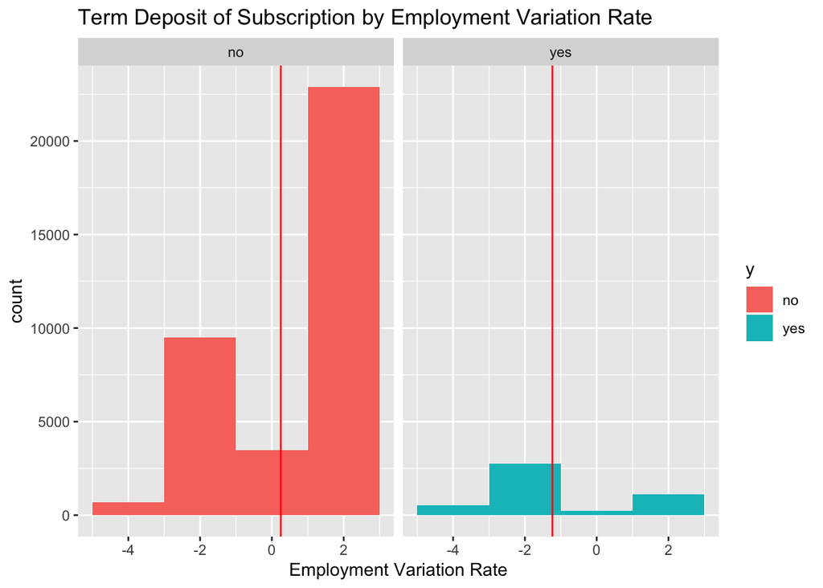

### 2.2.2 Main Analysis

Moving forward, we plan to dive into our different types of algorithms to determine the best-suited predictive model for our dataset. The classification goal is to predict if the client will subscribe (yes/no) to a term deposit (variable y). The list below will further clarify why we chose each method and how we plan to build the best-suited predictive model to determine our primary question.

**Decision Tree**

- A decision tree is a classification algorithm that supports non linearity. Decision trees can provide understandable explanations over the prediction and make it easier to interpret comparison for categorical independent variables.. It is one way to display an algorithm that only contains conditional control statements. Use 70% of our dataset as training data and 30% as our test data.

**General Logistic Regression**

- In contrast to linear regression where the dependent variable is continuous, the logistic regression binary classification model uses a different method of estimating the parameters (logistic function) to give results with lower variances. The output of the logistic regression will be a probability (0 ≤ x ≤1), and can be used to predict the binary 0 or 1 as the output.

**k-Nearest Neighbors (k-NN)**

- In k-NN, we explore the features’ neighborhood and assume the test data point to be similar to them and derive the output. When k-NN is used for classification, the output can be calculated as the class with the highest frequency from the K-most similar instances.
- Use 70% of our dataset as training data and 30% as our test data.

We will fit each model to implement a predictive model. Additionally, we will use Confusion Matrix to return accuracy rates for each method. Finally, we will calculate and plot the ROC curve to return AUC rates for each of the three methods.

# 3 Extra-Credit Method: Support Vector Machine (SVM)

Support vector machine (SVM) was used because it is a method of supervised learning that can be used for both classification and regression problems. SVM supports both linear and non-linear solutions using the kernel trick. It is good at pattern recognition which is fitting for the dataset that we have [5]. SVM constructs a high dimensional space, the hyperplane that separates the data into 2 categories with its particular linear classifiers based on the margin maximization principle. More importantly, it has a higher accuracy with less computational power. In using a hyperplane that provides the best generalization for the margin between the 2 data categories that we chose to be factors affecting the decision for the long term deposit [6].

[5] Adankon M., Cheriet M. (2009) Support Vector Machine. In: Li S.Z., Jain A. (eds) Encyclopedia of Biometrics. Springer, Boston, MA.

[6] Ashanira Mat Deris, Azlan Mohd Zain, Roselina Sallehuddin, Overview of Support Vector Machine in Modeling Machining Performances, Procedia Engineering, Volume 24, 2011, Pages 308-312, ISSN 1877-7058

# 4 Result

There are many metrics to evaluate our methods, however, we will be using Confusion matrix/Accuracy and ROC/AUC to determine which algorithm performed the best.

## 4.1 Descriptive Analysis

### Decision Tree

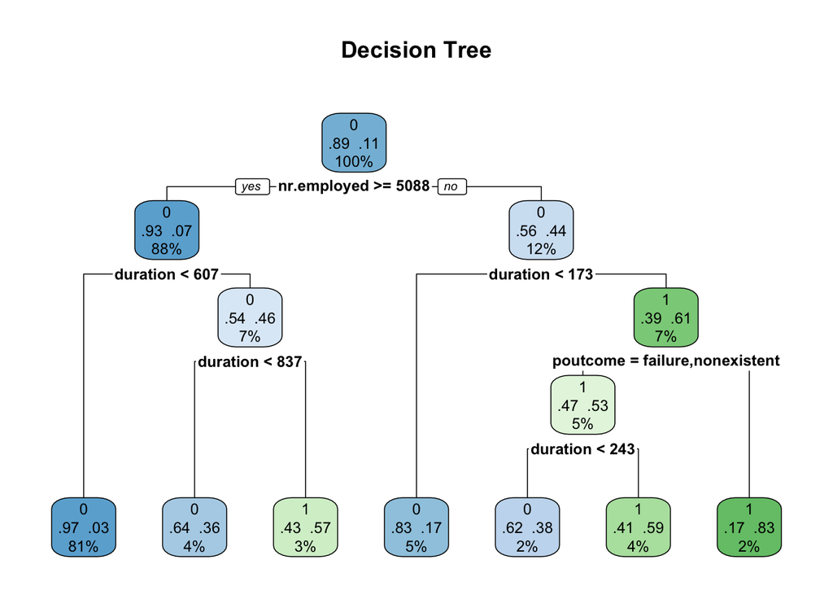

```
## Confusion Matrix and Statistics
##
##           Reference
## Prediction     0     1
##          0 10560   404
##          1   680   712
##
##                Accuracy : 0.9123
##                  95% CI : (0.9071, 0.9172)
##     No Information Rate : 0.9097
##     P-Value [Acc > NIR] : 0.1614
##
##                   Kappa : 0.5196
##
##  Mcnemar's Test P-Value : <2e-16
##
##             Sensitivity : 0.9395
##             Specificity : 0.6380
##          Pos Pred Value : 0.9632
##          Neg Pred Value : 0.5115
##              Prevalence : 0.9097
##          Detection Rate : 0.8546
##    Detection Prevalence : 0.8873
##       Balanced Accuracy : 0.7887
##
##        'Positive' Class : 0
##
```

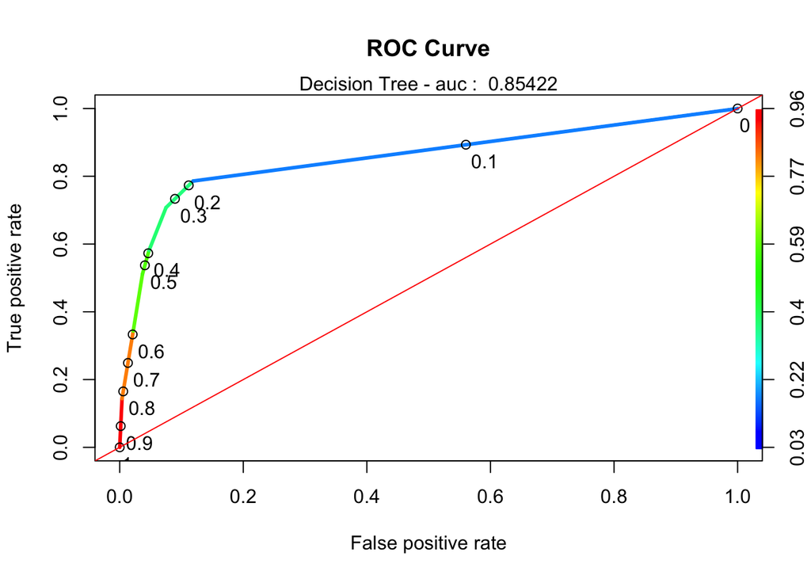

### General Logistic Regression

```
##
## Call:
## glm(formula = y ~ age + job + marital + education + default +
##     housing + loan + contact + month + duration + day_of_week +
##     campaign + pdays + previous + poutcome + emp.var.rate + cons.price.idx +
##     cons.conf.idx + euribor3m + nr.employed, family = "binomial",
##     data = train)
##
## Deviance Residuals:
##     Min       1Q   Median       3Q      Max
## -5.9514  -0.3035  -0.1876  -0.1335   3.1540
##
## Coefficients: (1 not defined because of singularities)
##                                Estimate Std. Error z value Pr(>|z|)
## (Intercept)                  -2.365e+02  4.589e+01  -5.154 2.55e-07 ***
## age                           1.706e-03  2.914e-03   0.586 0.558120
## jobblue-collar               -1.423e-01  9.450e-02  -1.505 0.132227
## jobentrepreneur              -6.015e-02  1.465e-01  -0.411 0.681331
## jobhousemaid                 -3.979e-02  1.743e-01  -0.228 0.819436
## jobmanagement                -8.341e-02  1.035e-01  -0.806 0.420091
## jobretired                    2.946e-01  1.271e-01   2.319 0.020400 *
## jobself-employed             -2.445e-01  1.443e-01  -1.695 0.090079 .
## jobservices                  -1.056e-01  1.032e-01  -1.023 0.306128
## jobstudent                    3.047e-01  1.333e-01   2.286 0.022275 *
##  [ reached getOption("max.print") -- omitted 44 rows ]
## ---
## Signif. codes:  0 '***' 0.001 '**' 0.01 '*' 0.05 '.' 0.1 ' ' 1
##
## (Dispersion parameter for binomial family taken to be 1)
##
##     Null deviance: 20299  on 28831  degrees of freedom
## Residual deviance: 12030  on 28779  degrees of freedom
## AIC: 12136
##
## Number of Fisher Scoring iterations: 10
```

```
## Confusion Matrix and Statistics
##
##           Reference
## Prediction     0     1
##          0 10350   533
##          1   614   859
##
##                Accuracy : 0.9072
##                  95% CI : (0.9019, 0.9122)
##     No Information Rate : 0.8873
##     P-Value [Acc > NIR] : 4.468e-13
##
##                   Kappa : 0.5472
##
##  Mcnemar's Test P-Value : 0.01817
##
##             Sensitivity : 0.61710
##             Specificity : 0.94400
##          Pos Pred Value : 0.58316
##          Neg Pred Value : 0.95102
##              Prevalence : 0.11266
##          Detection Rate : 0.06952
##    Detection Prevalence : 0.11921
##       Balanced Accuracy : 0.78055
##
##        'Positive' Class : 1
##
```

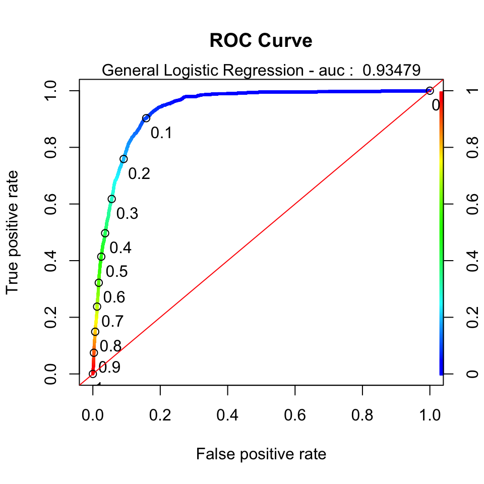

### K-Nearest Neighbor

[output not shown]

```
## Confusion Matrix and Statistics
##
##
## bank_knn_pred     0     1
##             0 10429   684
##             1   535   708
##
##                Accuracy : 0.9013
##                  95% CI : (0.896, 0.9065)
##     No Information Rate : 0.8873
##     P-Value [Acc > NIR] : 2.895e-07
##
##                   Kappa : 0.4824
##
##  Mcnemar's Test P-Value : 2.246e-05
##
##             Sensitivity : 0.5086
##             Specificity : 0.9512
##          Pos Pred Value : 0.5696
##          Neg Pred Value : 0.9385
##              Prevalence : 0.1127
##          Detection Rate : 0.0573
##    Detection Prevalence : 0.1006
##       Balanced Accuracy : 0.7299
##
##        'Positive' Class : 1
##
```

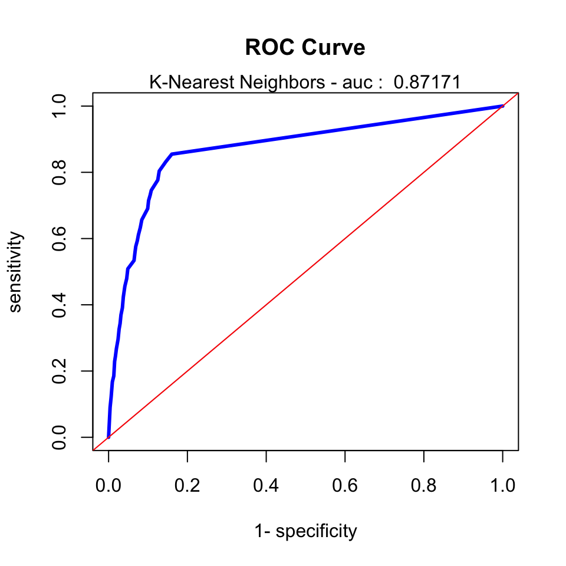

## 4.2 Inferential Analysis

For our confusion matrices, we will look at the accuracy, sensitivity, and specificity of each method. Accuracy measures all our correct responses compared to the overall responses. Sensitivity measures the value of true positives over all actual positives. Specificity measures the value of true negatives over all actual negatives. The higher the accuracy, sensitivity, and specificity rates, the better performing our algorithms. We must look at all the factors to determine the overall performance.

| **Decision Tree** | Results |
| --- | --- |
| Accuracy | 0.9123 |
| Sensitivity | 0.9395 |
| Specificty | 0.6380 |
| AUC | 0.85422 |

| **Logistic Regression** | Results |
| --- | --- |
| Accuracy | 0.9072 |
| Sensitivity | 0.61710 |
| Specificty | 0.94400 |
| AUC | 0.93479 |

| **KNN** | Results |
| --- | --- |
| Accuracy | 0.9013 |
| Sensitivity | 0.5086 |
| Specificty | 0.9512 |
| AUC | 0.87171 |

All of our algorithms return closely similar accuracies/misclassification rates. Decision tree returned the highest accuracy (0.9123) and sensitivity rate (0.9395). k-NN returned the highest specificity rate. However, from our ROC plots, logistic regression returns the highest AUC value (0.93479). The accuracy and specificity rates of our logistic regression model did perform high as well. For this reasoning, we will determine logistic regression as the main predictive model for whether a client will sign on to a long-term deposit.

# 5 Extra-Credit Method Results

| **SVM (Kernel Fit)** | Results |
| --- | --- |
| Accuracy | 0.9030 |
| Sensitivity | 0.9781 |
| Specificty | 0.3118 |
| Pos Pred Value | 0.9180 |
| Neg Pred Value | 0.6439 |
| Agreement True | 0.90304 |
| Agreement False | 0.09605 |

| **SVM (Gaussian Fit)** | Results |
| --- | --- |
| Accuracy | 0.9113 |
| Sensitivity | 0.9743 |
| Specificty | 0.4152 |
| Pos Pred Value | 0.9292 |
| Neg Pred Value | 0.6721 |
| Agreement True | 0.9113 |
| Agreement False | 0.0887 |

As this is a marginalized model, it is only good as a model to further enhance and aid the current models that we currently have since it does not take into account single factors, but the factors overall. It will be good to use SVM over a cluster of factors against the decision. Hence in this study, it may not be the best fit model for the given dataset, but it gives an idea of the overall relationship between the factors and the result. SVM can be considered a model for predicting whether a client will sign onto a long-term deposit when used together with other models that specify the factor.

# 6 Session Information (R-Code)

```r
knitr::opts_chunk$set(echo=FALSE,message=FALSE,warning=FALSE)
set.seed(1)
library(ggplot2)
library(knitr)
library(magrittr)
library(dplyr)
library(tidyverse)
library(ggcorrplot)
library(rpart)
library(rpart.plot)
library(ISLR)
library(caret)
library(gbm)
library(ROCR)
library(corrplot)
library(MASS)
library(caTools)
library(rsample)
library(class)
library(kknn)
library(AUC)
library(rmarkdown)
library(e1071)
library(xtable)
library(kableExtra)
library(devtools)
library(pander)
library(kernlab)
setwd("/Users/trucle/Desktop/STA\ 138/Bank/bank-additional")
# for this project we will be using the bank-additional-full.csv to do our analysis on.
bank_additional_full <- read.csv("bank-additional-full.csv", sep=";", stringsAsFactors = F, header = T)

# this allows for the data to be separated rather than being mushed together.
# to see how many rows have missing data
sum(!complete.cases(bank_additional_full))
sapply(bank_additional_full, function(x) sum(is.na(x)))
write.csv(bank_additional_full, "cleaned_bank_additional_full.csv")
# this write the clean data into a separate csv that we can use to work with
bank <- read.csv("cleaned_bank_additional_full.csv")[-1]
# -1 to get rid of them counting the # of rows


bank$age <- as.numeric(bank$age)
bank$duration <- as.numeric(bank$duration)
bank$campaign <- as.numeric(bank$campaign)
bank$pdays <- as.numeric(bank$pdays)
bank$previous <- as.numeric(bank$previous)
bank$emp.var.rate <- as.numeric(bank$emp.var.rate)
bank$cons.price.idx <- as.numeric(bank$cons.price.idx)
bank$cons.conf.idx <- as.numeric(bank$cons.conf.idx)
bank$nr.employed <- as.numeric(bank$nr.employed)

bank$job = fct_explicit_na(bank$job, "missing")
bank$marital = fct_explicit_na(bank$marital, "missing")
bank$education = fct_explicit_na(bank$education, "missing")
bank$default = fct_explicit_na(bank$default, "missing")
bank$loan = fct_explicit_na(bank$loan, "missing")
bank$contact = fct_explicit_na(bank$contact, "missing")
bank$poutcome = fct_explicit_na(bank$poutcome, "missing")
bank$day_of_week = fct_explicit_na(bank$day_of_week, "missing")
bank$housing = fct_explicit_na(bank$housing, "missing")
bank$month = fct_explicit_na(bank$month, "missing")
bank$y =ifelse(bank$y =='yes',1,0) # transforming 'yes' category into a binary 1=yes 0=no
str(bank)
kable(summary(bank), format = "html",col.names = colnames(bank)) %>%
  kable_styling(font_size = 10, full_width = FALSE)
kbl(prop.table(table(bank$y)), booktabs = TRUE )
pandoc.table(summary(bank$age), style="rmarkdown")
##### Category: Age
gg <- ggplot(bank)
# histogram plot for the distribution of age
his_age = gg + geom_histogram(aes(x=age), color = "black", fill ="white", binwidth = 1) +
  ggtitle("Age Distribution")+
  xlab("Age") + ylab("Counts")+
  geom_vline(aes(xintercept=mean(age), color="red"))+
  theme(legend.position = "none")

# made outliers data points red
mean_age <- bank_additional_full %>% group_by(y) %>% summarize(grp.mean=mean(age))
his_age_sub = ggplot (bank_additional_full, aes(x=age)) +
  geom_histogram(color = "black", fill = "green", binwidth = 1) +
  ggtitle('Subscription of Term Deposit by Age') + ylab('Count') + xlab('Age') +
  facet_grid(cols=vars(y))+
  scale_x_continuous(breaks = seq(0,100,5)) +
  geom_vline(data=mean_age, aes(xintercept=grp.mean), color="red", linetype="dashed") + geom_vline(data=bank_additional_full, aes(xintercept=mean(age)), color="black")
# this output two histograms for comparison, left histogram is for Age Distribution and the right histogram is for Subscription by Age. The black line shows the mean of the age superimposed onto the histograms and the dashed red line shows the mean of the age that subscriped onto the term deposit.
his_age
his_age_sub
age_<-bank_additional_full %>%
  group_by(age) %>%
  summarize(age.cnt = n(), pct.con.yes = mean(y=="yes")*100) %>%
  arrange(desc(age.cnt)) %>%
  head()
kbl(age_, booktabs = TRUE, caption = "Age Percentage to Subscribe",format = "html")%>%
  kable_styling(full_width = TRUE, position = "left",font_size = 10)
# Category: Education
#Bar graph for education
gg_edu=ggplot(bank, aes(x = education, fill=education))+geom_bar()+ggtitle("Distribution of Education Levels")
# Subscription by Education
edu_sub = ggplot(data = bank_additional_full, aes(x=education, fill=y)) +
         geom_bar() +
         ggtitle("Term Deposit Subscription based on Education Level") +
         xlab(" Education Level") +
         guides(fill=guide_legend(title="Subscription of Term Deposit"))
# need to use the bank_additional_full dataset to get the two layers bar graphs.

edu_<-bank_additional_full %>%
  group_by(education) %>%
  summarize(edu.cnt = n(), pct.con.yes = mean(y=="yes")*100) %>%
  arrange(desc(edu.cnt)) %>%
  head()
# Percentage of Yes within each group based on their education level
t2<-kbl(edu_, booktabs = TRUE, caption = "Education Percentage to Subscribe", format="html")


gg_edu
edu_sub
t2 %>%
  kable_styling(full_width = TRUE, font_size = 10)

# Category: Job
# bar graph for job
gg_job = ggplot(bank, aes(x = job, fill=job))+geom_bar()+ggtitle("Distribution of Jobs")
# subscription by job title
job_sub = ggplot(data = bank_additional_full, aes(x=job, fill=y)) +
         geom_bar() +
         ggtitle("Term Deposit Subscription based on Job Position") +
         xlab(" Job Position") +
         guides(fill=guide_legend(title="Subscription of Term Deposit"))
gg_job
job_sub
# Percentage of Yes in each group based on their job title
job_<-bank_additional_full %>%
  group_by(job) %>%
  summarize(job.cnt = n(), pct.con.yes = mean(y=="yes")*100) %>%
  arrange(desc(job.cnt)) %>%
  head()

kbl(job_, booktabs = TRUE, caption = "Job Percentage to Subscribe")%>%
  kable_styling(full_width = TRUE, font_size = 10)
# Category: Marital Statues
# bar chart for marital status
gg_marital = ggplot(bank, aes(x = marital, fill=marital)) + geom_bar() +
  ggtitle("Distribution of Martial Status") + xlab("Martial Status")
# Subscription by marital status
marital_sub = ggplot(bank_additional_full, aes(x = marital, fill=y)) + geom_bar() +
  ggtitle("Distribution of Martial Status by subscription") + xlab("Martial Status")
```

```r
mar_<-bank_additional_full %>%
  group_by(marital) %>%
  summarize(marital.cnt = n(), pct.con.yes = mean(y=="yes")*100) %>%
  arrange(desc(marital.cnt)) %>%
  head()

kbl(mar_, booktabs = TRUE, caption = "marital Percentage to Subscribe")%>%
  kable_styling(full_width = TRUE, font_size = 10)
# Percentage of Yes in each group based on their Marital status
gg_marital
marital_sub
# Consumer Price Index Distribution Graphs
# Using GGplot, I constructed a bar graph to show the distribution of the consumer price index
bar_price.idx=ggplot(bank, aes(x = cons.price.idx, fill=cons.price.idx)) + geom_bar()+
  geom_vline(aes(xintercept=mean(cons.price.idx)),color="red")+ggtitle("Consumer Price Index with Red Mean Line")

bar_cpi_sub = ggplot(bank_additional_full, aes(x = cons.price.idx, fill=y)) + geom_bar() +
  ggtitle("Term Deposit of Subscription by Consumer Price Index") + xlab("Consumer Price Index")

cpi_<-bank_additional_full %>%
  group_by(cons.price.idx) %>%
  summarize(cpi.cnt = n(), pct.con.yes = mean(y=="yes")*100) %>%
  arrange(desc(cpi.cnt)) %>%
  head()

kbl(cpi_, booktabs = TRUE, caption = "Consumer Price Index Percentage to Subscribe")%>%
  kable_styling(full_width = TRUE, font_size = 10)
bar_price.idx
bar_cpi_sub
# Category: Consumer Confidence Index Graphs
bar_conf.idx=ggplot(bank, aes(x = cons.conf.idx, fill=cons.conf.idx)) + geom_bar()+
  ggtitle("Consumer Confidence Index Bar Graph")
bar_cci_sub = ggplot(bank_additional_full, aes(x = cons.conf.idx, fill=y)) + geom_bar() +
  ggtitle("Term Deposit of Subscription by Consumer Confidence Index") + xlab("Consumer Confidence Index")

cci_<-bank_additional_full %>%
  group_by(cons.conf.idx) %>%
  summarize(cci.cnt = n(), pct.con.yes = mean(y=="yes")*100) %>%
  arrange(desc(cci.cnt)) %>%
  head()

kbl(cci_, booktabs = TRUE, caption = "Consumer Confidence Index Percentage to Subscribe")%>%
  kable_styling(full_width = TRUE, font_size = 10 )

bar_conf.idx
bar_cci_sub

# Category: Campaign
bar_campaign=ggplot(bank, aes(x = campaign, fill=campaign)) + geom_bar()+
  ggtitle("Campaign")
bar_campaign_sub = ggplot(bank_additional_full, aes(x = campaign, fill=y)) + geom_bar() +
  ggtitle("Term Deposit of Subscription by Campaign") + xlab("Campaign")+xlim(c(min=0, max=30))

cam_<-bank_additional_full %>%
  group_by(campaign) %>%
  summarize(contact.cnt = n(), pct.con.yes = mean(y=="yes")*100) %>%
  arrange(desc(contact.cnt)) %>%
  head()
kbl(cam_, booktabs = TRUE, caption = "Campaign Percentage to Subscribe")%>%
  kable_styling(full_width = TRUE, font_size = 10)
bar_campaign
bar_campaign_sub
# Category : Duration
bar_duration=ggplot(bank, aes(x = duration, fill=duration)) + geom_bar(fill="blue")+
  ggtitle("Duration Distribution")
mean_duration <- bank_additional_full %>% group_by(y) %>% summarize(grp.mean=mean(duration))
his_dur_sub = ggplot(bank_additional_full, aes(x = duration, fill=y)) + geom_histogram(binwidth = 2) +
  facet_grid(cols=vars(y))+
  ggtitle("Term Deposit of Subscription by Duration") + xlab("Duration")+coord_cartesian(xlim = c(0,2000), ylim = c(0,1000))+geom_vline(data=mean_duration, aes(xintercept = grp.mean), color="red")

dur_<-bank_additional_full %>%
  group_by(duration) %>%
  summarize(contact.cnt = n(), pct.con.yes = mean(y=="yes")*100) %>%
  arrange(desc(contact.cnt)) %>%
  head()
kbl(dur_, booktabs = TRUE, caption = "Duration Percentage to Subscribe")%>%
  kable_styling(full_width = TRUE, font_size = 10)
bar_duration
his_dur_sub
# Employment Variation Rate
his_evr = ggplot(bank, aes(x = emp.var.rate, fill=emp.var.rate)) + geom_histogram(fill="blue")+
  ggtitle("Employment Variation Rate")
mean_evr <- bank_additional_full %>% group_by(y) %>% summarize(grp.mean=mean(emp.var.rate))
his_evr_sub = ggplot(bank_additional_full, aes(x = emp.var.rate, fill=y)) + geom_histogram(binwidth = 2) +facet_grid(cols=vars(y))+ggtitle("Term Deposit of Subscription by Employment Variation Rate") + xlab("Employment Variation Rate")+geom_vline(data=mean_evr, aes(xintercept = grp.mean), color="red")

evr_<-bank_additional_full %>%
  group_by(emp.var.rate) %>%
  summarize(contact.cnt = n(), pct.con.yes = mean(y=="yes")*100) %>%
  arrange(desc(contact.cnt)) %>%
  head()
kbl(evr_, booktabs = TRUE, caption = "Employment Variation Rate Percentage to Subscribe")%>%
  kable_styling(full_width = TRUE, font_size = 10)
his_evr
his_evr_sub
#Split the Training / Testing data
set.seed(1)
split = sample.split(bank$y,SplitRatio = 0.70)
train = subset(bank, split == TRUE)
test = subset(bank, split == FALSE)
# Model 1: Decision Tree with training set
tree_model <-rpart(y ~ .,
                   data=train,
                   method ="class")
rpart.plot(tree_model,
           main="Decision Tree",
           type=2,
           extra = 104,
           fallen.leaves = TRUE)
# type= 2 : draw the split labels below the node labels
# extra = 104 : class model with a response having more than two levels
#Evaluating the Decision Tree Model
#prediction model
pred<-predict(tree_model,test,type = "class")
#confusion matrix
confusionMatrix(as.factor(test$y),as.factor(pred))
# calculate ROC curve
pred.DT = predict(tree_model, newdata = test, type = 'prob')
rocr.pred = prediction(predictions=pred.DT[,2], labels = test$y)
rocr.perf = performance(rocr.pred, measure = "tpr", x.measure = "fpr")
rocr.auc = as.numeric(performance(rocr.pred, "auc")@y.values)
# print ROC AUC
invisible(rocr.auc)
#plot ROC curve
roc_curve<-{plot(rocr.perf,
     lwd = 3, colorize = TRUE,
     print.cutoffs.at = seq(0, 1, by = 0.1),
     text.adj = c(-0.2, 1.7),
     main = 'ROC Curve')
mtext(paste('Decision Tree - auc : ', round(rocr.auc, 5)))
abline(0, 1, col = "red", lty = 1)}
roc_curve
# Model 2: General Logistic Regression
invisible(table(train$y))
model_glm <- glm(formula = y ~ age+ job + marital + education + default + housing +
    loan + contact + month + duration+ day_of_week + campaign + pdays +
    previous + poutcome + emp.var.rate + cons.price.idx + cons.conf.idx +
    euribor3m + nr.employed, family = "binomial", data = train)
options(max.print = 50)
summary(model_glm)
bank_glm_pred <- predict(model_glm, test, type = "response")
bank_glm_pred_label <- as.factor(ifelse(bank_glm_pred>.3, "1", "0"))
confusionMatrix(factor(bank_glm_pred_label), factor(test$y), positive = "1")
bank_glm_roc <- prediction(bank_glm_pred, test$y)
rocr.perf_glm=performance(bank_glm_roc, "tpr", "fpr")
bank_glm_auc <- performance(bank_glm_roc, "auc")
auc_glm<-bank_glm_auc@y.values[[1]]
# print ROC AUC
invisible(auc_glm)
#plot ROC curve
roc_curve<-{plot(rocr.perf_glm,
     lwd = 3, colorize = TRUE,
     print.cutoffs.at = seq(0, 1, by = 0.1),
     text.adj = c(-0.2, 1.7),
     main = 'ROC Curve')
mtext(paste('General Logistic Regression - auc : ', round(auc_glm, 5)))
abline(0, 1, col = "red", lty = 1)}
roc_curve
# Model 3: K-Nearest Neighbor
# have to make the y into a factor in order to run the knn code
set.seed(1)
split = sample.split(bank$y,SplitRatio = 0.70)
train = subset(bank, split == TRUE)
test = subset(bank, split == FALSE)
train$y <- as.factor(train$y)
test$y <- as.factor(test$y)
options(max.print = 20)
model.KNN <- kknn( y ~ age+ job + marital + education + default + housing +
    loan + contact + month + duration+ day_of_week + campaign + pdays +
    previous + poutcome + emp.var.rate + cons.price.idx + cons.conf.idx +
    euribor3m + nr.employed, train, test, k=5, distance = 2,scale=FALSE, getOption(max.print=20))
options(max.print = 50)
summary(model.KNN)
bank_knn_pred <-NULL
bank_knn_pred <- predict(model.KNN, test, type="raw")
bank_knn_pred_label <- table(bank_knn_pred, test$y)
confusionMatrix(bank_knn_pred_label, positive = "1")
pb_bank <- NULL
pb_bank <- predict(model.KNN, test, type="prob")
pb_bank <- as.data.frame(pb_bank)
pred.KNN <- data.frame(test$y, pb_bank$"1")
labels <- as.factor(ifelse(pred.KNN$test.y=="1", 1, 0))
predictions <- pred.KNN$pb_bank..1.
auc_knn<-auc(roc(predictions, labels), min = 0, max = 1)
```

```r
#plot ROC curve
{plot(roc(predictions, labels), col="blue",
      lwd=3,
      main= "ROC Curve")
  mtext(paste('K-Nearest Neighbors - auc : ', round(auc_knn, 5)))
  abline(0, 1, col = "red", lty = 1)}
```